# import library that needed

```python
import numpy as np
import pandas as pd
import statsmodels.api as sm
import matplotlib.pyplot as plt
from sklearn.model_selection import train_test_split

import warnings
warnings.filterwarnings('ignore')
```

### setting tampilan dataframe pandas

```python
# setting supaya bisa lihat isi kolom dan baris
pd.set_option('display.max_columns', 200)
pd.set_option('display.max_rows', 200)

# setting supaya output menghasilkan 2 angka dibelakang koma
pd.options.display.float_format = '{:.2f}'.format
```

### data diperoleh dari https://www.kaggle.com/datasets/seanangelonathanael/bank-target-marketing?resource=download

### revoke the dataset

```python
df = pd.read_csv('Bank Target Marketing Dataset.csv')
df.info()
```

```
<class 'pandas.core.frame.DataFrame'>
RangeIndex: 56373 entries, 0 to 56372
Data columns (total 17 columns):
 #   Column     Non-Null Count  Dtype
---  ------     --------------  -----
 0   age        56373 non-null  int64
 1   job        56373 non-null  object
 2   marital    56373 non-null  object
 3   education  56373 non-null  object
 4   default    56373 non-null  object
 5   balance    56373 non-null  int64
 6   housing    56373 non-null  object
 7   loan       56373 non-null  object
 8   contact    56373 non-null  object
 9   day        56373 non-null  int64
 10  month      56373 non-null  object
 11  duration   56373 non-null  int64
 12  campaign   56373 non-null  int64
 13  pdays      56373 non-null  int64
 14  previous   56373 non-null  int64
 15  poutcome   56373 non-null  object
 16  deposit    56373 non-null  object
dtypes: int64(7), object(10)
memory usage: 7.3+ MB
```

### dataset terdiri atas 56.373 baris dan 17 kolom

```python
df.head()
```

[output not shown]

### The dataset consists of 17 columns, each representing the following attributes:

• age: Customer's age.

• job: Customer's occupation.

• marital: Customer's marital status.

• education: Customer's level of education.

• default: Whether the customer has credit in default.

• balance: Customer's average yearly balance.

• housing: Whether the customer has a housing loan.

• loan: Whether the customer has a personal loan.

• contact: Type of communication contact with the customer.

• day: Last contact day of the month.

• month: Last contact month of the year.

• duration: Last contact duration in seconds.

• campaign: Number of contacts performed during this campaign for the customer.

• pdays: Number of days since the customer was last contacted from a previous campaign.

• previous: Number of contacts performed before this campaign for the customer.

• poutcome: Outcome of the previous marketing campaign.

• deposit: Whether the customer subscribed to a term deposit.

### check missing value

```python
df.isna().sum()
```

```
age          0
job          0
marital      0
education    0
default      0
balance      0
housing      0
loan         0
contact      0
day          0
month        0
duration     0
campaign     0
pdays        0
previous     0
poutcome     0
deposit      0
dtype: int64
```

### - variabel deposit

```python
df['deposit'].value_counts()
```

```
no     45795
yes    10578
Name: deposit, dtype: int64
```

```python
df['y_deposit'] = [1 if x == 'yes' else 0 for x in df['deposit']]
```

### - variabel job

```python
df['job'].value_counts()
```

```
management       12024
blue-collar      11676
technician        9420
admin.            6505
services          5077
retired           3042
self-employed     1984
entrepreneur      1815
unemployed        1660
housemaid         1514
student           1298
unknown            358
Name: job, dtype: int64
```

```python
display(pd.crosstab(df.job, df.y_deposit, normalize = 'index'))
```

| y_deposit job | 0 | 1 |
| --- | --- | --- |
| admin. | 0.81 | 0.19 |
| blue-collar | 0.88 | 0.12 |
| entrepreneur | 0.86 | 0.14 |
| housemaid | 0.86 | 0.14 |
| management | 0.78 | 0.22 |
| retired | 0.66 | 0.34 |
| self-employed | 0.81 | 0.19 |
| services | 0.85 | 0.15 |
| student | 0.59 | 0.41 |
| technician | 0.82 | 0.18 |
| unemployed | 0.76 | 0.24 |
| unknown | 0.81 | 0.19 |

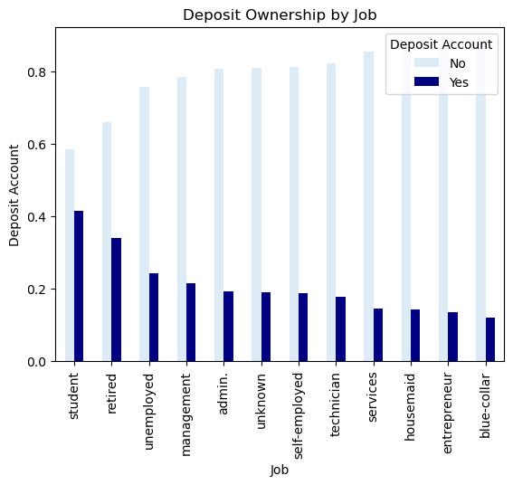

```python
pd.crosstab(df.job, df.y_deposit, normalize = 'index').sort_values([1],
            ascending = False).plot(kind='bar', color = ['#DDEBF7','#000080'])
plt.title('Deposit Ownership by Job')
plt.xlabel('Job')
plt.ylabel('Deposit Account')
plt.legend(title='Deposit Account', loc = 'upper right', labels = ['No', 'Yes'])
plt.show()
```

### dapat dilihat bahwa responden yang memiliki status bekerja sebagai blue-collar memiliki deposit yang paling rendah, oleh sebab itu akan dijadikan base dalam pemodelan

### membuat dummy dari variabel job

```python
df['student'] = [1 if x == "student" else 0 for x in df['job']]
df['retired'] = [1 if x == "retired" else 0 for x in df['job']]
df['unemployment'] = [1 if x == "unemployed" else 0 for x in df['job']]
df['management'] = [1 if x == "management" else 0 for x in df['job']]
df['admin'] = [1 if x == "admin." else 0 for x in df['job']]
df['self_employed'] = [1 if x == "self-employed" else 0 for x in df['job']]
df['technician'] = [1 if x == "technician" else 0 for x in df['job']]
df['services'] = [1 if x == "services" else 0 for x in df['job']]
df['housemaid'] = [1 if x == "housemaid" else 0 for x in df['job']]
df['enterpreneur'] = [1 if x == "entrepreneur" else 0 for x in df['job']]
df['unknown'] = [1 if x == "unknown" else 0 for x in df['job']]
df['blue-collar'] = [1 if x == "blue-collar" else 0 for x in df['job']]
```

### - variabel marital

```python
df['marital'].value_counts()
```

```
married     33565
single      16308
divorced     6500
Name: marital, dtype: int64
```

```python
df['have_marriage'] = [1 if x == "married" or y == "divorced" else 0 for x,y in zip(df['marital'],df['marital'])]
```

### - variabel education

```python
df['education'].value_counts()
```

```
secondary    28678
tertiary     16990
primary       8351
unknown       2354
Name: education, dtype: int64
```

```python
display(pd.crosstab(df.education, df.y_deposit, normalize = 'index'))
```

| y_deposit education | 0 | 1 |
| --- | --- | --- |
| primary | 0.86 | 0.14 |
| secondary | 0.83 | 0.17 |
| tertiary | 0.77 | 0.23 |
| unknown | 0.79 | 0.21 |

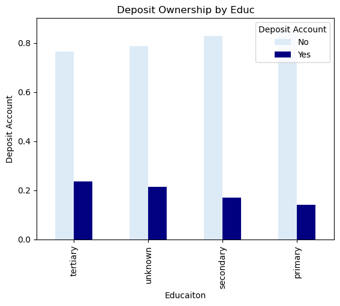

```python
pd.crosstab(df.education, df.y_deposit, normalize = 'index').sort_values([1],
            ascending = False).plot(kind='bar', color = ['#DDEBF7','#000080'])
plt.title('Deposit Ownership by Educ')
plt.xlabel('Educaiton')
plt.ylabel('Deposit Account')
plt.legend(title='Deposit Account', loc = 'upper right', labels = ['No', 'Yes'])
plt.show()
```

### dapat dilihat bahwa responden yang memiliki pendidikan primer memiliki deposit yang paling rendah, oleh sebab itu akan dijadikan base dalam pemodelan

```python
df['pend_tersier'] = [1 if x == "tertiary" else 0 for x in df['education']]
df['pend_unk'] = [1 if x == "unknown" else 0 for x in df['education']]
df['pend_secondary'] = [1 if x == "secondary" else 0 for x in df['education']]
df['pend_primary'] = [1 if x == "primary" else 0 for x in df['education']]
```

### - variabel default

```python
df['default'].value_counts()
```

```
no     55390
yes      983
Name: default, dtype: int64
```

```python
df['x_default'] = [1 if x == 'yes' else 0 for x in df['default']]
```

### - variabel housing

```python
df['housing'].value_counts()
```

```
yes    30411
no     25962
Name: housing, dtype: int64
```

```python
df['x_housing'] = [1 if x == 'yes' else 0 for x in df['housing']]
```

### - variabel loan

```python
df['loan'].value_counts()
```

```
no     47669
yes     8704
Name: loan, dtype: int64
```

```python
df['x_loan'] = [1 if x == 'yes' else 0 for x in df['loan']]
```

### setelah variabel dikuantifikasi, selanjutnya variabel dibuat menjadi 1 dataframe

```python
dataf = df[['y_deposit',
            'student','retired','unemployment','management','admin','self_employed','technician',
            'services','housemaid','enterpreneur','unknown','blue-collar',
            'have_marriage',
            'pend_tersier','pend_unk','pend_secondary','pend_primary',
            'x_default',
            'x_housing',
            'x_loan']]
```

```python
dataf.describe()
```

|  | y_deposit | student | retired | unemployment | management | admin | self_employed | technician | services | housemaid | enterpreneur | unknown | blue-collar | have_marriage | pend_tersier | pend_unk | pend_secondary | pend_primary | x_default | x_housing | x_loan |
| --- | --- | --- | --- | --- | --- | --- | --- | --- | --- | --- | --- | --- | --- | --- | --- | --- | --- | --- | --- | --- | --- |
| count | 56373.00 | 56373.00 | 56373.00 | 56373.00 | 56373.00 | 56373.00 | 56373.00 | 56373.00 | 56373.00 | 56373.00 | 56373.00 | 56373.00 | 56373.00 | 56373.00 | 56373.00 | 56373.00 | 56373.00 | 56373.00 | 56373.00 | 56373.00 | 56373.00 |
| mean | 0.19 | 0.02 | 0.05 | 0.03 | 0.21 | 0.12 | 0.04 | 0.17 | 0.09 | 0.03 | 0.03 | 0.01 | 0.21 | 0.71 | 0.30 | 0.04 | 0.51 | 0.15 | 0.02 | 0.54 | 0.15 |
| std | 0.39 | 0.15 | 0.23 | 0.17 | 0.41 | 0.32 | 0.18 | 0.37 | 0.29 | 0.16 | 0.18 | 0.08 | 0.41 | 0.45 | 0.46 | 0.20 | 0.50 | 0.36 | 0.13 | 0.50 | 0.36 |
| min | 0.00 | 0.00 | 0.00 | 0.00 | 0.00 | 0.00 | 0.00 | 0.00 | 0.00 | 0.00 | 0.00 | 0.00 | 0.00 | 0.00 | 0.00 | 0.00 | 0.00 | 0.00 | 0.00 | 0.00 | 0.00 |
| 25% | 0.00 | 0.00 | 0.00 | 0.00 | 0.00 | 0.00 | 0.00 | 0.00 | 0.00 | 0.00 | 0.00 | 0.00 | 0.00 | 0.00 | 0.00 | 0.00 | 0.00 | 0.00 | 0.00 | 0.00 | 0.00 |
| 50% | 0.00 | 0.00 | 0.00 | 0.00 | 0.00 | 0.00 | 0.00 | 0.00 | 0.00 | 0.00 | 0.00 | 0.00 | 0.00 | 1.00 | 0.00 | 0.00 | 1.00 | 0.00 | 0.00 | 1.00 | 0.00 |
| 75% | 0.00 | 0.00 | 0.00 | 0.00 | 0.00 | 0.00 | 0.00 | 0.00 | 0.00 | 0.00 | 0.00 | 0.00 | 0.00 | 1.00 | 1.00 | 0.00 | 1.00 | 0.00 | 0.00 | 1.00 | 0.00 |
| max | 1.00 | 1.00 | 1.00 | 1.00 | 1.00 | 1.00 | 1.00 | 1.00 | 1.00 | 1.00 | 1.00 | 1.00 | 1.00 | 1.00 | 1.00 | 1.00 | 1.00 | 1.00 | 1.00 | 1.00 | 1.00 |

### model logit dengan base blue-collar dan pend_primary

```python
dataz = df[['y_deposit',
            'student','retired','unemployment','management','admin','self_employed','technician',
            'services','housemaid','enterpreneur','unknown',
            'have_marriage',
            'pend_tersier','pend_unk','pend_secondary',
            'x_default',
            'x_housing',
            'x_loan']]
```

```python
# create X and y test
X_train, X_test, y_train, y_test = train_test_split(dataz.loc[:, dataz.columns != 'y_deposit'],
                                                    dataz.loc[:, dataz.columns == 'y_deposit'],
                                                    test_size=0.2, random_state=42)
```

```python
# menambah konstanta
X_train = sm.add_constant(X_train)
X_test = sm.add_constant(X_test)
```

```python
# model logit
logit_x = sm.Logit(y_train, X_train)
result_x = logit_x.fit()
print(result_x.summary())
```

```
Optimization terminated successfully.
         Current function value: 0.456786
         Iterations 6
                           Logit Regression Results
==============================================================================
Dep. Variable:              y_deposit   No. Observations:                45098
Model:                          Logit   Df Residuals:                    45079
Method:                           MLE   Df Model:                           18
Date:                Wed, 13 Mar 2024   Pseudo R-squ.:                 0.05485
Time:                        15:54:58   Log-Likelihood:                -20600.
converged:                       True   LL-Null:                       -21796.
Covariance Type:            nonrobust   LLR p-value:                     0.000
==================================================================================
                     coef    std err          z      P>|z|      [0.025      0.975]
----------------------------------------------------------------------------------
const             -1.3377      0.051    -26.315      0.000      -1.437      -1.238
student            0.8491      0.076     11.105      0.000       0.699       0.999
retired            0.9301      0.056     16.699      0.000       0.821       1.039
unemployment       0.4499      0.074      6.092      0.000       0.305       0.595
management         0.1404      0.051      2.771      0.006       0.041       0.240
admin              0.3186      0.050      6.377      0.000       0.221       0.417
self_employed      0.0600      0.076      0.790      0.430      -0.089       0.209
technician         0.1188      0.047      2.525      0.012       0.027       0.211
services           0.0670      0.056      1.188      0.235      -0.044       0.178
housemaid         -0.1314      0.090     -1.461      0.144      -0.308       0.045
enterpreneur      -0.1814      0.087     -2.074      0.038      -0.353      -0.010
unknown           -0.0357      0.156     -0.230      0.818      -0.341       0.269
have_marriage     -0.2893      0.028    -10.366      0.000      -0.344      -0.235
pend_tersier       0.5213      0.051     10.262      0.000       0.422       0.621
pend_unk           0.2839      0.071      3.998      0.000       0.145       0.423
pend_secondary     0.2383      0.044      5.443      0.000       0.152       0.324
x_default         -0.4842      0.119     -4.074      0.000      -0.717      -0.251
x_housing         -0.7268      0.026    -27.739      0.000      -0.778      -0.675
x_loan            -0.5661      0.041    -13.757      0.000      -0.647      -0.485
==================================================================================
```

### terdapat empat variabel yang tidak signifikan. selanjutnya keempat variabel tersebut diuji terlebih dahulu menggunakan wald test

```python
print(result_x.wald_test('(self_employed = 0, services = 0, housemaid = 0, unknown = 0)'))
```

```
<Wald test (chi2): statistic=[[4.96672285]], p-value=0.2907290136596747, df_denom=4>
```

### karena nilai p-value untuk uji wald test = 0,290 > 0.05, maka H0 diterima, artinya variabel tersebut tidak berpengaruh secara signifikan terhadap variabel dependen

### drop variabel yang tidak signifikan

```python
X_train = X_train.drop(columns = ['self_employed', 'services', 'housemaid', 'unknown'])
X_test = X_test.drop(columns = ['self_employed', 'services', 'housemaid', 'unknown'])
```

### relogit

```python
# model logit
logit_x = sm.Logit(y_train, X_train)
result_x = logit_x.fit()
print(result_x.summary())
```

```
Optimization terminated successfully.
         Current function value: 0.456842
         Iterations 6
                           Logit Regression Results
==============================================================================
Dep. Variable:              y_deposit   No. Observations:                45098
Model:                          Logit   Df Residuals:                    45083
Method:                           MLE   Df Model:                           14
Date:                Wed, 13 Mar 2024   Pseudo R-squ.:                 0.05474
Time:                        15:54:59   Log-Likelihood:                -20603.
converged:                       True   LL-Null:                       -21796.
Covariance Type:            nonrobust   LLR p-value:                     0.000
==================================================================================
                     coef    std err          z      P>|z|      [0.025      0.975]
----------------------------------------------------------------------------------
const             -1.3398      0.047    -28.539      0.000      -1.432      -1.248
student            0.8322      0.072     11.562      0.000       0.691       0.973
retired            0.9210      0.051     18.231      0.000       0.822       1.020
unemployment       0.4358      0.070      6.255      0.000       0.299       0.572
management         0.1231      0.042      2.923      0.003       0.041       0.206
admin              0.3008      0.044      6.907      0.000       0.215       0.386
technician         0.1010      0.040      2.556      0.011       0.024       0.178
enterpreneur      -0.1971      0.084     -2.357      0.018      -0.361      -0.033
have_marriage     -0.2923      0.028    -10.487      0.000      -0.347      -0.238
pend_tersier       0.5418      0.049     11.117      0.000       0.446       0.637
pend_unk           0.2980      0.070      4.276      0.000       0.161       0.435
pend_secondary     0.2589      0.043      6.093      0.000       0.176       0.342
x_default         -0.4848      0.119     -4.079      0.000      -0.718      -0.252
x_housing         -0.7233      0.026    -27.922      0.000      -0.774      -0.673
x_loan            -0.5639      0.041    -13.714      0.000      -0.645      -0.483
==================================================================================
```

### menghitung nilai prediksi

```python
# menghitung nilai prediksi
y_predict = result_x.predict(X_test)
y_predik = [1 if a >= 0.5 else 0 for a in y_predict]

# menghitung confusion matriks
from sklearn.metrics import confusion_matrix, accuracy_score

cm = confusion_matrix(y_test, y_predik)
print ("Confusion Matrix : \n", cm)

# accuracy score of the model
print('Test accuracy = ', accuracy_score(y_test, y_predik))
```

```
Confusion Matrix :
 [[9156   19]
 [2075   25]]
Test accuracy =  0.814279379157428
```

### nilai akurasinya adalah 81,4%

### nilai akurasi dapat merepresentasikan kemampuan model dalam mengklasifikasi apakah individu akan memiliki kategori deposit atau tidak

### menghitung odds ratio masing-masing variabel

```python
np.exp(result_x.params)
```

```
const            0.26
student          2.30
retired          2.51
unemployment     1.55
management       1.13
admin            1.35
technician       1.11
enterpreneur     0.82
have_marriage    0.75
pend_tersier     1.72
pend_unk         1.35
pend_secondary   1.30
x_default        0.62
x_housing        0.49
x_loan           0.57
dtype: float64
```

saran: dapat menggunakan metode lain seperti RFE dalam pemilihan variabel dan menggunakan metode klasifikasi lain seperti random forest